# Lab 9

### Exercise 5

Let’s see if the apparent trend in the plot is something more than natural variation. Fit a linear model called m_bty to predict average professor score by average beauty rating. Write out the equation for the linear model and interpret the slope. Is average beauty score a statistically significant predictor? Does it appear to be a practically significant predictor?

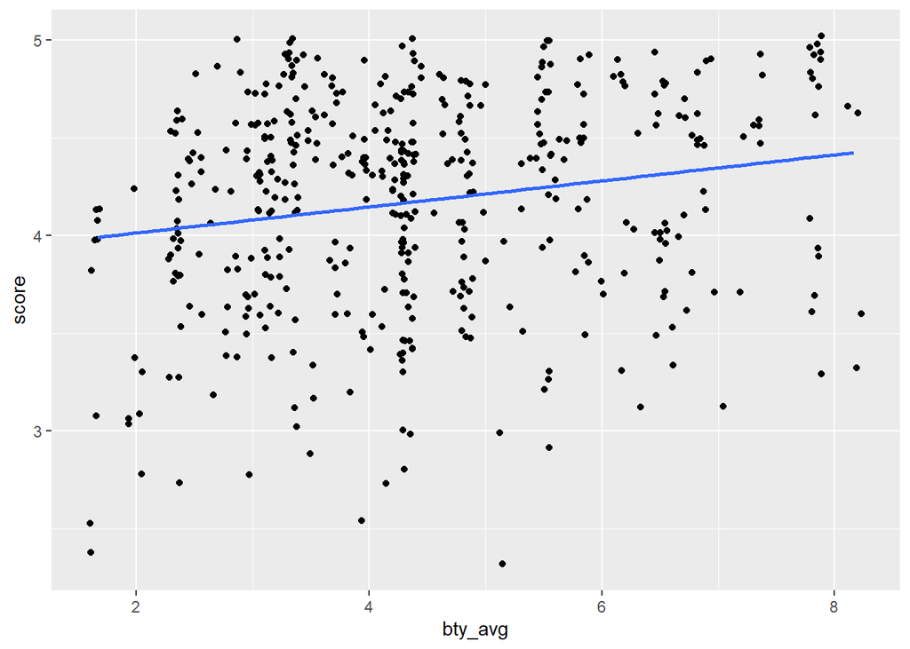

```r
ggplot(data = evals, aes(x = bty_avg, y = score)) +
  geom_jitter() +
  geom_smooth(method = "lm", se = FALSE)
```

```r
m_bty <- lm(evals$score ~ evals$bty_avg)
summary(m_bty)
```

```
##
## Call:
## lm(formula = evals$score ~ evals$bty_avg)
##
## Residuals:
##     Min      1Q  Median      3Q     Max
## -1.9246 -0.3690  0.1420  0.3977  0.9309
##
## Coefficients:
##               Estimate Std. Error t value Pr(>|t|)
## (Intercept)    3.88034    0.07614   50.96  < 2e-16 ***
## evals$bty_avg  0.06664    0.01629    4.09 5.08e-05 ***
## ---
## Signif. codes:  0 '***' 0.001 '**' 0.01 '*' 0.05 '.' 0.1 ' ' 1
##
## Residual standard error: 0.5348 on 461 degrees of freedom
## Multiple R-squared:  0.03502,    Adjusted R-squared:  0.03293
## F-statistic: 16.73 on 1 and 461 DF,  p-value: 5.083e-05
```

Let’s see if the apparent trend in the plot is something more than natural variation. Fit a linear model called m_bty to predict average professor score by average beauty rating. Write out the equation for the linear model and interpret the slope. Is average beauty score a statistically significant predictor? Does it appear to be a practically significant predictor?

The equation for the linear model is:

$$y = 3.88034 + 0.06664$$

Where y is the predicted score of the professor based on x, the average beauty of the professor.

In this case, the slope is slightly positive at 0.067 and it indicates that as beauty increases the average score of professors on evaluations also increases marginally.

Based on the low r-squared values (both adjusted and predicted) and the low p-value, it appears as though average beauty is not a practically significant predictor of evaluation score. The low r-squared values indicate that another model may be suited for prediction. Though the low p-value indicates that the relationship between these variables is statistically significant at a level of 0.001.

### Exercise 6

Use residual plots to evaluate whether the conditions of least squares regression are reasonable. Provide plots and comments for each one (see the Simple Regression Lab for a reminder of how to make these).

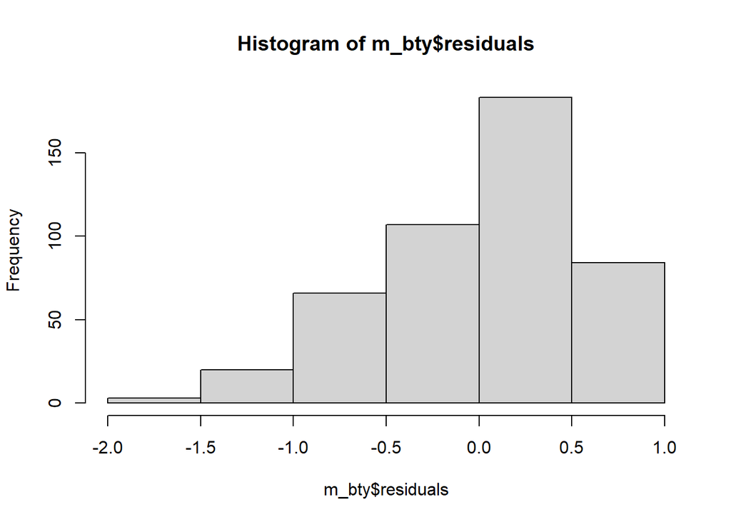

```r
hist(m_bty$residuals)
```

A histogram shows the distribution of the residuals to be left skewed and not normally distributed.

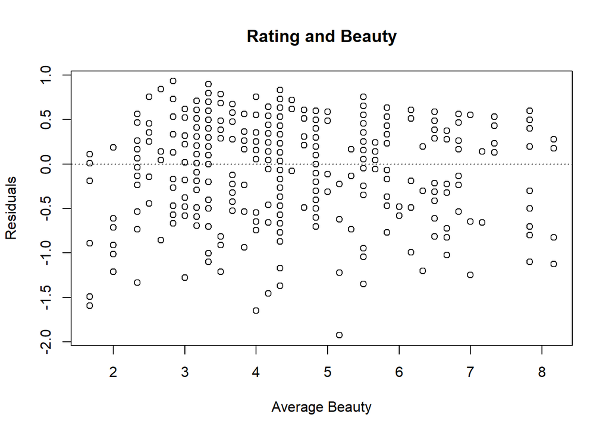

```r
plot(m_bty$residuals ~ evals$bty_avg, ylab="Residuals", xlab="Average Beauty",
main="Rating and Beauty")
abline(h = 0, lty = 3)  # adds a horizontal dashed line at y = 0
```